# Topicos Estatísticos-Final

# Modelo Random Florest

Os modelos de ramdom florest são florestas randomizadas e oque isso significa ? significa que são conjuntos de árvores de decisões onde cada árvore terá características e parametros distintos , ele comparará várias cobinações de variaveis explicativas e de parametros por último sera retornado o modelo com melhor performance.

```r
library(randomForest)
```

Gera o modelo

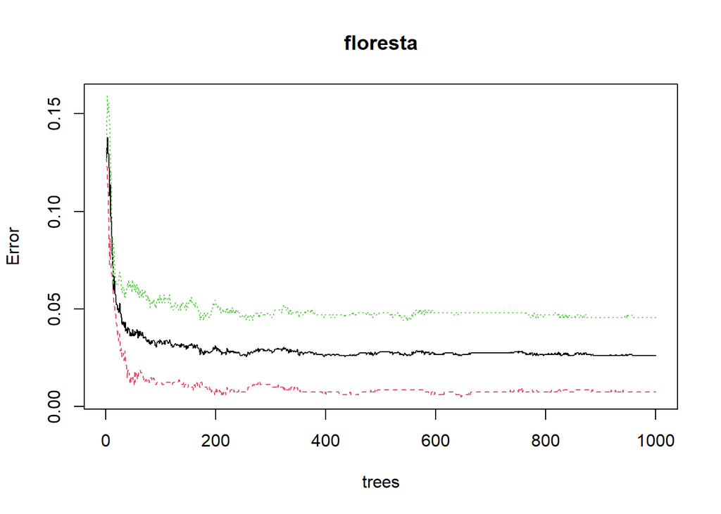

```r
floresta = randomForest(as.factor(treino$DECISAO_y) ~ .,data=treino, ntree=1000,importance=T)

plot(floresta)
```

Previsão para os dados de treino

```r
#treino$previsao = predict(floresta,treino)


confusao = table(predict(floresta,treino),treino$DECISAO_y)

confusionMatrix(confusao)
```

```
## Confusion Matrix and Statistics
##
##
##            Aprovado Negado
##   Aprovado      800     23
##   Negado          0    745
##
##                Accuracy : 0.9853
##                  95% CI : (0.9781, 0.9907)
##     No Information Rate : 0.5102
##     P-Value [Acc > NIR] : < 2.2e-16
##
##                   Kappa : 0.9706
##
##  Mcnemar's Test P-Value : 4.49e-06
##
##             Sensitivity : 1.0000
##             Specificity : 0.9701
##          Pos Pred Value : 0.9721
##          Neg Pred Value : 1.0000
##              Prevalence : 0.5102
##          Detection Rate : 0.5102
##    Detection Prevalence : 0.5249
##       Balanced Accuracy : 0.9850
##
##        'Positive' Class : Aprovado
##
```

# Observando as metricas para os Dados de Teste

```r
teste$previsao = predict(floresta,teste)


confusao = table(teste$previsao,teste$DECISAO_y)


confusionMatrix(confusao)
```

```
## Confusion Matrix and Statistics
##
##
##            Aprovado Negado
##   Aprovado      194     25
##   Negado          6    167
##
##                Accuracy : 0.9209
##                  95% CI : (0.8896, 0.9456)
##     No Information Rate : 0.5102
##     P-Value [Acc > NIR] : < 2.2e-16
##
##                   Kappa : 0.8415
##
##  Mcnemar's Test P-Value : 0.001225
##
##             Sensitivity : 0.9700
##             Specificity : 0.8698
##          Pos Pred Value : 0.8858
##          Neg Pred Value : 0.9653
##              Prevalence : 0.5102
##          Detection Rate : 0.4949
##    Detection Prevalence : 0.5587
##       Balanced Accuracy : 0.9199
##
##        'Positive' Class : Aprovado
##
```

O modelo aparentemente presenta uma alta taxa de acerto , ou seja , isso pode ser um indicativo de Sobre-ajuste ou sobreajuste (do inglês: overfitting) é um termo usado em estatística para descrever quando um modelo estatístico se ajusta muito bem ao conjunto de dados anteriormente observado, mas se mostra ineficaz para prever novos resultados, ou seja , o modelo não está aprendendo, apenas decorando o comportamento dos dados.

Avaliação de Performance

```r
taxaacerto = (confusao[1] + confusao[4]) / sum(confusao)
taxaacerto
```

```
## [1] 0.9209184
```

# seleção de Atributos

Por que selecionar atributos?

Dentre os atributos, existem aquelas onde as informações contidas vão importar mais para o problema que você deseja resolver.

Mas por que existe essa diferença? Existem vários fatores que podem influenciar nessa, sendo os mais comuns:

1- Muitos dados faltantes naquela coluna, impossibilitando qualquer conclusão. Exemplo: Mais da metade das células em branco/vazias em uma coluna determinada.

2- Colunas com alta entre si. Exemplo: Se estou trabalhando com colunas de carros, tendo uma coluna a quantidade de rodas e outra correspondente a quantidade de eixos no carro, temos uma correspondente total, pois cada eixo, há exatamente duas rodas. Assim, ao fazer esses dados, existem duas análises redundantes, aumentando a quantidade de dados a ser processada.

3- Muitos atributos. É ainda que na sua base de dados a ser trabalhada, existe um grande número de colunas, passando das milhares, ou mesmo, como em mais colunas do que alinhadas. Assim, haverá um grande custo de processamento que poderia selecionar quais atributos deveríamos nos atentar.

Aplicamos um método de seleção de atributos

```r
credit<-  credit %>% filter(credit$RendaPresumida == "NAO_INFORMADO")
importancia  = randomForest(as.factor(treino$DECISAO_y) ~ ., data = treino)
col = importance(importancia)
col
```

```
##                      MeanDecreaseGini
## Sexo                        31.011527
## Idade                      205.053434
## Escolaridade                74.239686
## statusReceitaFederal         1.524811
## CategoriaProfissao          98.005953
## RendaPresumida              56.916211
## Socio                       17.287502
## UF                          88.513302
## Regiao                      38.924479
## vezes                        0.000000
```

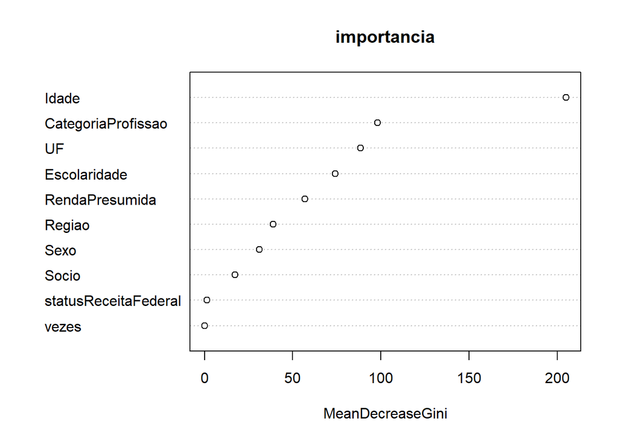

```r
varImpPlot(importancia)
```

Gera o modelo

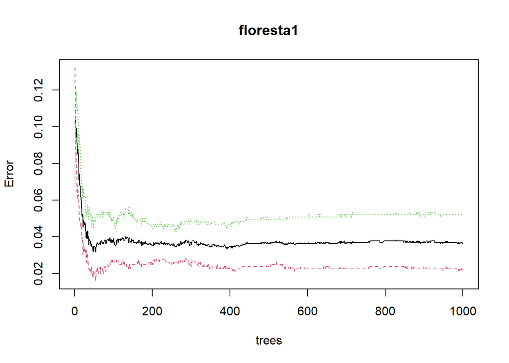

```r
#credit$DECISAO_y
floresta1 = randomForest(as.factor(treino$DECISAO_y) ~Idade+
                          CategoriaProfissao+UF+Escolaridade+RendaPresumida,data=treino, ntree=1000,importance=T)

plot(floresta1)
```

```r
# table(credit$RendaPresumida)
# table(credit$Escolaridade)
```

Previsão

```r
  #teste$previsao = predict(floresta1,teste)

 confusao = table(predict(floresta1,teste),teste$DECISAO_y)
  confusionMatrix(confusao)
```

```
## Confusion Matrix and Statistics
##
##
##            Aprovado Negado
##   Aprovado      185     38
##   Negado         15    154
##
##                Accuracy : 0.8648
##                  95% CI : (0.8269, 0.8971)
##     No Information Rate : 0.5102
##     P-Value [Acc > NIR] : < 2.2e-16
##
##                   Kappa : 0.7288
##
##  Mcnemar's Test P-Value : 0.002512
##
##             Sensitivity : 0.9250
##             Specificity : 0.8021
##          Pos Pred Value : 0.8296
##          Neg Pred Value : 0.9112
##              Prevalence : 0.5102
##          Detection Rate : 0.4719
##    Detection Prevalence : 0.5689
##       Balanced Accuracy : 0.8635
##
##        'Positive' Class : Aprovado
##
```

Avaliação de Performance

```r
 taxaacerto = (confusao[1] + confusao[4]) / sum(confusao)
 taxaacerto
```

```
## [1] 0.8647959
```

# Conclusão

Após as análises vimos que os modelos Random Florest obtiveram as melhores metricas , sendo forte candidados para o deploy(implementação) , ainda seria necessário uma avaliação critériosa para verificar se de fato o modelo está sobre -ajustado , após essa análise e possíveis correções de hiperparametros poderiamos enfim implementar o modelo .

### Refências

O que é Deploy em programação? [Link](https://kenzie.com.br/blog/o-que-e-deploy/#:~:text=O%20verbo%20deploy%2C%20em%20ingl%C3%AAs,que%20teve%20seu%20desenvolvimento%20conclu%C3%ADdo.)

Seleção de atributos [Link](https://medium.com/@airtonneto/sele%C3%A7%C3%A3o-de-atributos-para-data-science-e-machine-learning-2842c63fc59f)